# Google Data Analytics Certificate Case Study 1

Daniel Saiger

2022-06-02

## **Introduction**

In this notebook I am working on the Case Study 1 of the Google Data Analytics Professional Certificate. The Case Study is the last part of the 6-Month course.

My workflow will follow the six steps of the data analysis process: Ask, prepare, process, analyze, share, and act.

## **Scenario**

You are a junior data analyst working in the marketing analyst team at Cyclistic, a bike-share company in Chicago. The director of marketing believes the company’s future success depends on maximizing the number of annual memberships. Therefore, your team wants to understand how casual riders and annual members use Cyclistic bikes differently. From these insights, your team will design a new marketing strategy to convert casual riders into annual members. But first, Cyclistic executives must approve your recommendations, so they must be backed up with compelling data insights and professional data visualizations.

## **Characters & Teams involved**

- **Cyclistic:** A bike-share program that features more than 5,800 bicycles and 600 docking stations. Cyclistic sets itself apart by also offering reclining bikes, hand tricycles, and cargo bikes, making bike-share more inclusive to people with disabilities and riders who can’t use a standard two-wheeled bike. The majority of riders opt for traditional bikes; about 8% of riders use the assistive options. Cyclistic users are more likely to ride for leisure, but about 30% use them to commute to work each day.
- **Lily Moreno:** The director of marketing and your manager. Moreno is responsible for the development of campaigns and initiatives to promote the bike-share program. These may include email, social media, and other channels.
- **Cyclistic marketing analytics team:** A team of data analysts who are responsible for collecting, analyzing, and reporting data that helps guide Cyclistic marketing strategy. You joined this team six months ago and have been busy learning about Cyclistic’s mission and business goals — as well as how you, as a junior data analyst, can help Cyclistic achieve them.
- **Cyclistic executive team:** The notoriously detail-oriented executive team will decide whether to approve the recommended marketing program.

## **Step 1: Ask**

### Guiding Questions:

1. What is the problem I am trying to solve?
- Identify and understand the difference between casual riders and annual members
- Find ways to convert casual riders into annual members
2. How can my insights drive business decisions?
- The insights will support the marketing team in designing and choosing the right marketing strategy
- The insights will support in deciding if digital media can affect the marketing tactics
- If the right decisions are made based on the insights, they will ultimately help the company to reach a higher revenue

**Business Task:**

Define the key difference between casual riders and annual members. Give Advice on which marketing strategy and tactics could have the most impact on converting casual riders to annual members

## **Step 2: Prepare**

### Guiding Questions:

1. Where is the data located?
- The data is located locally on my computer. All Datasets can be found over https://divvy-tripdata.s3.amazonaws.com/index.html
2. How is the data organized?
- The data is organized in single csv files. Each file contains data for one month.
3. Are there issues with bias or credibility?
- Bias isn’t a problem beacuse the population of the dataset is the clients of the company as bike riders. It has full credibility for the same reason. It’s ROCCC because it’s reliable, original, comprehensive, current and cited.
4. How are you addressing licensing, privacy, security, and accessibility?
- The data is licensed by the company. Since the data doesn’t contain personal information, privacy, security, and accessibilityis are not a problem.
5. How did you verify the data’s integrity?
- The data is consistent and is formatted correctly.
6. How does it help you answer your question?
- It helps me generating the insights needed to resolve the business task.
7. Are there any problems with the data?
- It would be good if the data contained more demographic information about the individual riders. This would help to create insights and action recommendation for different groups of customers.

## **Step 3: Process**

### Tools used:

- Because of the high volume of data, R will be used to clean and analyze the data.
- The main dependency will be the tidyverse package

First, install dependencies, then all the .csv files will be merged in one dataframe

```r
library(tidyverse)
library(lubridate)
```

```r
library(ggplot2)
library(tibble)
library(dplyr)
```

```r
library(readr)
data_frame <- read_csv("E:/R/GA case Study/data.csv")
df <- as_tibble(data_frame)
```

```r
head(df)
```

```
## # A tibble: 6 x 13
##   ride_id rideable_type started_at          ended_at            start_station_n~
##   <chr>   <chr>         <dttm>              <dttm>              <chr>
## 1 A847FA~ docked_bike   2020-04-26 17:45:14 2020-04-26 18:12:03 Eckhart Park
## 2 5405B8~ docked_bike   2020-04-17 17:08:54 2020-04-17 17:17:03 Drake Ave & Ful~
## 3 5DD24A~ docked_bike   2020-04-01 17:54:13 2020-04-01 18:08:36 McClurg Ct & Er~
## 4 2A59BB~ docked_bike   2020-04-07 12:50:19 2020-04-07 13:02:31 California Ave ~
## 5 27AD30~ docked_bike   2020-04-18 10:22:59 2020-04-18 11:15:54 Rush St & Hubba~
## 6 356216~ docked_bike   2020-04-30 17:55:47 2020-04-30 18:01:11 Mies van der Ro~
## # ... with 8 more variables: start_station_id <dbl>, end_station_name <chr>,
## #   end_station_id <dbl>, start_lat <dbl>, start_lng <dbl>, end_lat <dbl>,
## #   end_lng <dbl>, member_casual <chr>
```

```r
colnames(df)
```

```
##  [1] "ride_id"            "rideable_type"      "started_at"
##  [4] "ended_at"           "start_station_name" "start_station_id"
##  [7] "end_station_name"   "end_station_id"     "start_lat"
## [10] "start_lng"          "end_lat"            "end_lng"
## [13] "member_casual"
```

```r
str(df)
```

```
## tibble [3,826,978 x 13] (S3: tbl_df/tbl/data.frame)
##  $ ride_id           : chr [1:3826978] "A847FADBBC638E45" "5405B80E996FF60D" "5DD24A79A4E006F4" "2A59BBDF5CDBA725" ...
##  $ rideable_type     : chr [1:3826978] "docked_bike" "docked_bike" "docked_bike" "docked_bike" ...
##  $ started_at        : POSIXct[1:3826978], format: "2020-04-26 17:45:14" "2020-04-17 17:08:54" ...
##  $ ended_at          : POSIXct[1:3826978], format: "2020-04-26 18:12:03" "2020-04-17 17:17:03" ...
##  $ start_station_name: chr [1:3826978] "Eckhart Park" "Drake Ave & Fullerton Ave" "McClurg Ct & Erie St" "California Ave & Division St" ...
##  $ start_station_id  : num [1:3826978] 86 503 142 216 125 173 35 434 627 377 ...
##  $ end_station_name  : chr [1:3826978] "Lincoln Ave & Diversey Pkwy" "Kosciuszko Park" "Indiana Ave & Roosevelt Rd" "Wood St & Augusta Blvd" ...
##  $ end_station_id    : num [1:3826978] 152 499 255 657 323 35 635 382 359 508 ...
##  $ start_lat         : num [1:3826978] 41.9 41.9 41.9 41.9 41.9 ...
##  $ start_lng         : num [1:3826978] -87.7 -87.7 -87.6 -87.7 -87.6 ...
##  $ end_lat           : num [1:3826978] 41.9 41.9 41.9 41.9 42 ...
##  $ end_lng           : num [1:3826978] -87.7 -87.7 -87.6 -87.7 -87.7 ...
##  $ member_casual     : chr [1:3826978] "member" "member" "member" "member" ...
##  - attr(*, "problems")= tibble [872,489 x 5] (S3: tbl_df/tbl/data.frame)
##   ..$ row     : int [1:872489] 2983224 2983245 2983262 2983263 2983263 2983274 2983274 2983285 2983311 2983311 ...
##   ..$ col     : chr [1:872489] "end_station_id" "start_station_id" "end_station_id" "start_station_id" ...
##   ..$ expected: chr [1:872489] "a double" "a double" "a double" "a double" ...
##   ..$ actual  : chr [1:872489] "TA1306000003" "TA1309000006" "TA1305000006" "TA1309000006" ...
##   ..$ file    : chr [1:872489] "'E:/R/GA case Study/data.csv'" "'E:/R/GA case Study/data.csv'" "'E:/R/GA case Study/data.csv'" "'E:/R/GA case Study/data.csv'" ...
##  - attr(*, "spec")=
##   .. cols(
##   ..   ride_id = col_character(),
##   ..   rideable_type = col_character(),
##   ..   started_at = col_datetime(format = ""),
##   ..   ended_at = col_datetime(format = ""),
##   ..   start_station_name = col_character(),
##   ..   start_station_id = col_double(),
##   ..   end_station_name = col_character(),
##   ..   end_station_id = col_double(),
##   ..   start_lat = col_double(),
##   ..   start_lng = col_double(),
##   ..   end_lat = col_double(),
##   ..   end_lng = col_double(),
##   ..   member_casual = col_character()
##   .. )
```

We can see that we have a dataframe with 13 columns and 3.826.978 Rows.

### **Clean the Data**

```r
#Renaming the Columns for better context

df <- rename(df
            ,"bike_id" = rideable_type
            ,"start_time"  = started_at
            ,"end_time" = ended_at
            ,"user_type" = member_casual)
```

```r
#Removing duplicate columns

df <- df %>% distinct(ride_id, .keep_all= TRUE)
```

```r
#Parsing the date columns to ensure consistency

df$start_time <- as.POSIXct(df$start_time, "%Y-%m-%d %H:%M:%S")
df$end_time <- as.POSIXct(df$end_time, "%Y-%m-%d %H:%M:%S")
```

```r
#Adding a column for the ride duration in minutes

df <- df %>% mutate(ride_time = as.numeric((end_time - start_time)/60))
```

```r
#Create seperate columns for year, month, day and hour for later aggregation

df <- df %>% mutate(year = paste(strftime(df$start_time,"%Y")))
df <- df %>% mutate(month = paste(strftime(df$start_time,"%Y"),
                            "-",
                            strftime(df$start_time, "%m")))
df <- df %>% mutate(day = paste(strftime(df$end_time,"%u")))
df <- df %>% mutate(hour = paste(strftime(df$start_time,"%H")))
```

## **Step 4: Analyze**

```r
summary(df)
```

```
##    ride_id            bike_id            start_time
##  Length:3826769     Length:3826769     Min.   :2020-04-01 00:00:30
##  Class :character   Class :character   1st Qu.:2020-07-19 19:40:26
##  Mode  :character   Mode  :character   Median :2020-09-06 17:57:23
##                                        Mean   :2020-09-29 06:04:25
##                                        3rd Qu.:2020-11-12 16:32:54
##                                        Max.   :2021-04-30 23:59:53
##
##     end_time                   start_station_name start_station_id
##  Min.   :2020-04-01 00:10:45   Length:3826769     Min.   :     2
##  1st Qu.:2020-07-19 20:20:04   Class :character   1st Qu.:   112
##  Median :2020-09-06 18:27:36   Mode  :character   Median :   225
##  Mean   :2020-09-29 06:30:42                      Mean   :  1502
##  3rd Qu.:2020-11-12 16:48:22                      3rd Qu.:   346
##  Max.   :2021-05-05 22:14:39                      Max.   :202480
##                                                   NA's   :588159
##  end_station_name   end_station_id     start_lat       start_lng
##  Length:3826769     Min.   :     2   Min.   :41.64   Min.   :-87.87
##  Class :character   1st Qu.:   112   1st Qu.:41.88   1st Qu.:-87.66
##  Mode  :character   Median :   226   Median :41.90   Median :-87.64
##                     Mean   :  1502   Mean   :41.90   Mean   :-87.64
##                     3rd Qu.:   347   3rd Qu.:41.93   3rd Qu.:-87.63
##                     Max.   :202480   Max.   :42.08   Max.   :-87.52
##                     NA's   :604825
##     end_lat         end_lng        user_type           ride_time
##  Min.   :41.54   Min.   :-88.07   Length:3826769     Min.   :-29049.97
##  1st Qu.:41.88   1st Qu.:-87.66   Class :character   1st Qu.:     7.80
##  Median :41.90   Median :-87.64   Mode  :character   Median :    14.35
##  Mean   :41.90   Mean   :-87.64                      Mean   :    26.27
##  3rd Qu.:41.93   3rd Qu.:-87.63                      3rd Qu.:    26.38
##  Max.   :42.16   Max.   :-87.44                      Max.   : 58720.03
##  NA's   :5004    NA's   :5004
##      year              month               day                hour
##  Length:3826769     Length:3826769     Length:3826769     Length:3826769
##  Class :character   Class :character   Class :character   Class :character
##  Mode  :character   Mode  :character   Mode  :character   Mode  :character
##
##
##
##
```

```r
# Distribution of the data

df %>% group_by(user_type) %>% summarise(count = length(ride_id), '%' = length(ride_id)/nrow(df)*100)
```

```
## # A tibble: 2 x 3
##   user_type   count   `%`
##   <chr>       <int> <dbl>
## 1 casual    1566952  40.9
## 2 member    2259817  59.1
```

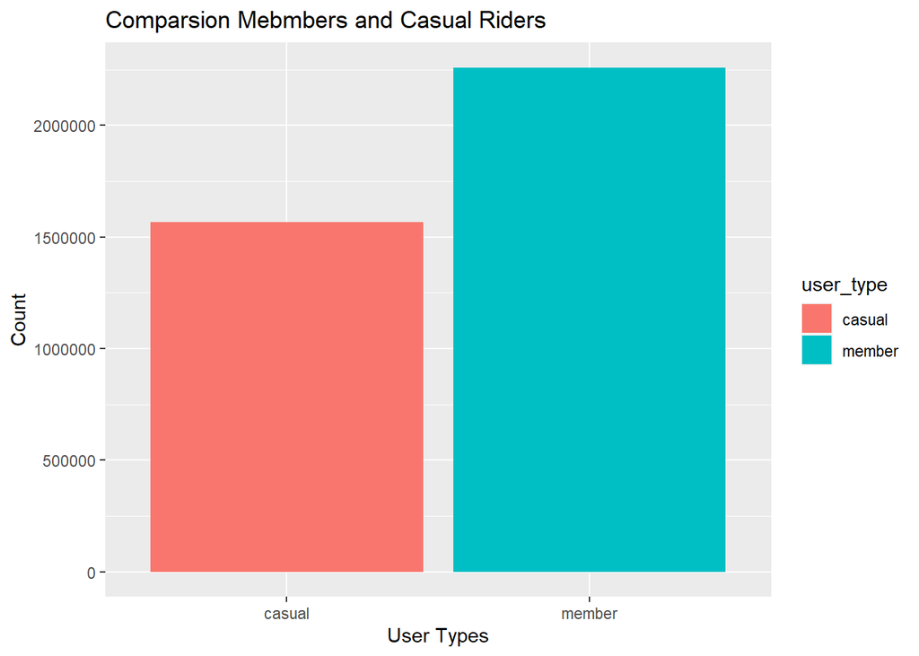

```r
#Function to resize the graphs
fig <- function(width, heigth){options(repr.plot.width = width, repr.plot.height = heigth)}
fig(10,8)

#Plotting the distribution
ggplot(df, aes(user_type, fill = user_type)) + geom_bar() + labs(x = "User Types", y = "Count", title = "Comparsion Mebmbers and Casual Riders")
```

**Findings:** * The Dataset contains more datapoints for members than for casual riders (~59% Members, ~41% Casual)

```r
#Number of Rides by Month

df %>% group_by(month) %>% summarise(count = length(ride_id)
    ,'%' = length(ride_id)/nrow(df)*100
    ,'casual_p' = sum(user_type == "casual")/ length(ride_id)*100
    ,'members_p' = sum(user_type == "member")/ length(ride_id)*100)
```

```
## # A tibble: 14 x 5
##    month      count     `%` casual_p members_p
##    <chr>      <int>   <dbl>    <dbl>     <dbl>
##  1 2020 - 04  84701  2.21       27.9      72.1
##  2 2020 - 05 200349  5.24       43.4      56.6
##  3 2020 - 06 342317  8.95       45.1      54.9
##  4 2020 - 07 550374 14.4        48.8      51.2
##  5 2020 - 08 623578 16.3        46.6      53.4
##  6 2020 - 09 532941 13.9        43.3      56.7
##  7 2020 - 10 389054 10.2        37.3      62.7
##  8 2020 - 11 259878  6.79       33.9      66.1
##  9 2020 - 12 131365  3.43       22.9      77.1
## 10 2021 - 01  96855  2.53       18.7      81.3
## 11 2021 - 02  49602  1.30       20.4      79.6
## 12 2021 - 03 228330  5.97       36.8      63.2
## 13 2021 - 04 336856  8.80       40.5      59.5
## 14 2021 - 05    569  0.0149     46.7      53.3
```

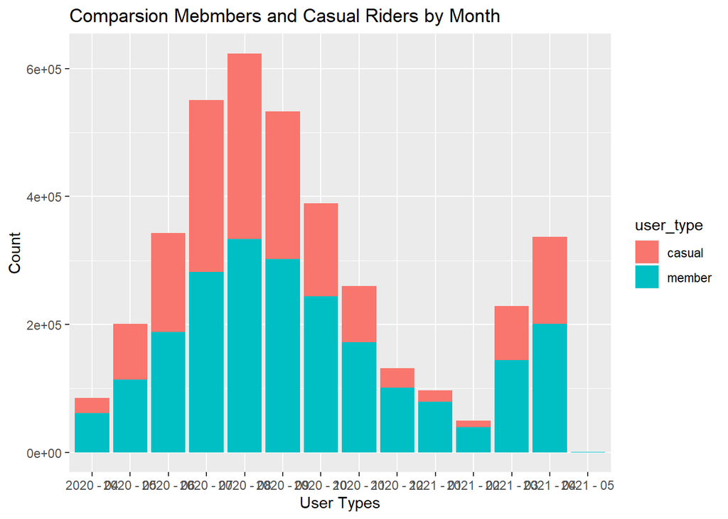

```r
fig(10,8)
ggplot(df, aes(month, fill = user_type)) + geom_bar() + labs(x = "User Types", y = "Count", title = "Comparsion Mebmbers and Casual Riders by Month")
```

**Findings:** * Members generally have more rides than casual riders * The number of rides is the highest in the months July, August, September and October. This could be correlated with the warm weather in these months. Room for further analysis

```r
#Get the number of rides on the different weekdays. 1 = Monday, 7 = Sunday

df %>% group_by(day) %>%
    summarise(count = length(ride_id)
    ,'%' = length(ride_id)/nrow(df)*100
    ,'casual_p' = sum(user_type == "casual")/ length(ride_id)*100
    ,'members_p' = sum(user_type == "member")/ length(ride_id)*100)
```

```
## # A tibble: 7 x 5
##   day    count   `%` casual_p members_p
##   <chr>  <int> <dbl>    <dbl>     <dbl>
## 1 1     466676  12.2     36.6      63.4
## 2 2     481411  12.6     34.4      65.6
## 3 3     500214  13.1     33.9      66.1
## 4 4     503699  13.2     35.0      65.0
## 5 5     563791  14.7     39.6      60.4
## 6 6     714283  18.7     50.7      49.3
## 7 7     596695  15.6     50.1      49.9
```

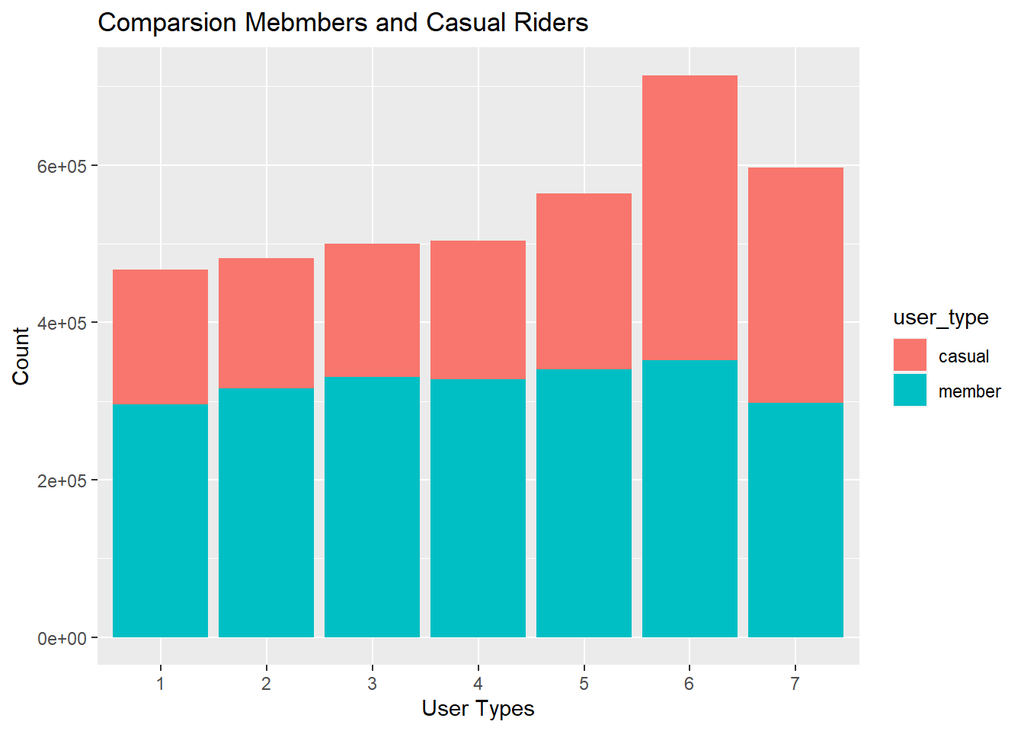

```r
#visualizing the daily riders and daily riders per month
fig(16,10)
ggplot(df, aes(day, fill = user_type)) + geom_bar() + labs(x = "User Types", y = "Count", title = "Comparsion Mebmbers and Casual Riders")
```

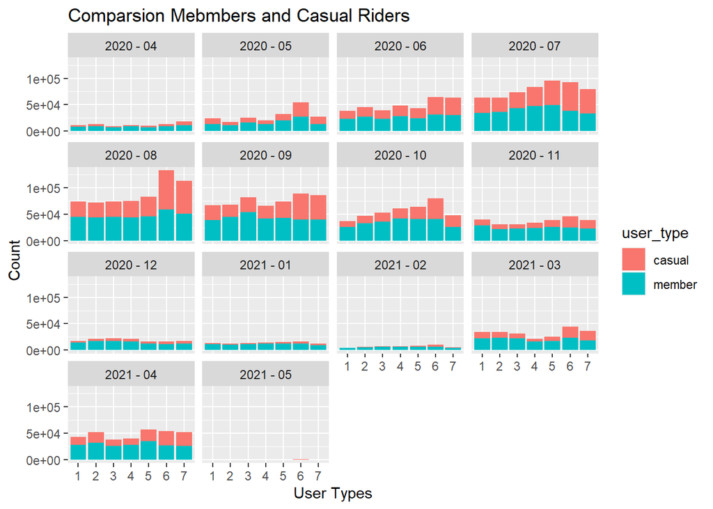

```r
ggplot(df, aes(day, fill = user_type)) + geom_bar() + labs(x = "User Types", y = "Count", title = "Comparsion Mebmbers and Casual Riders") + facet_wrap(~month)
```

**Findings:**

- The number of rides is highest on the weekend (Friday, Saturday, Sunday)
- The number of casual riders increases on the weekend
- Under the week, mainly members take rides

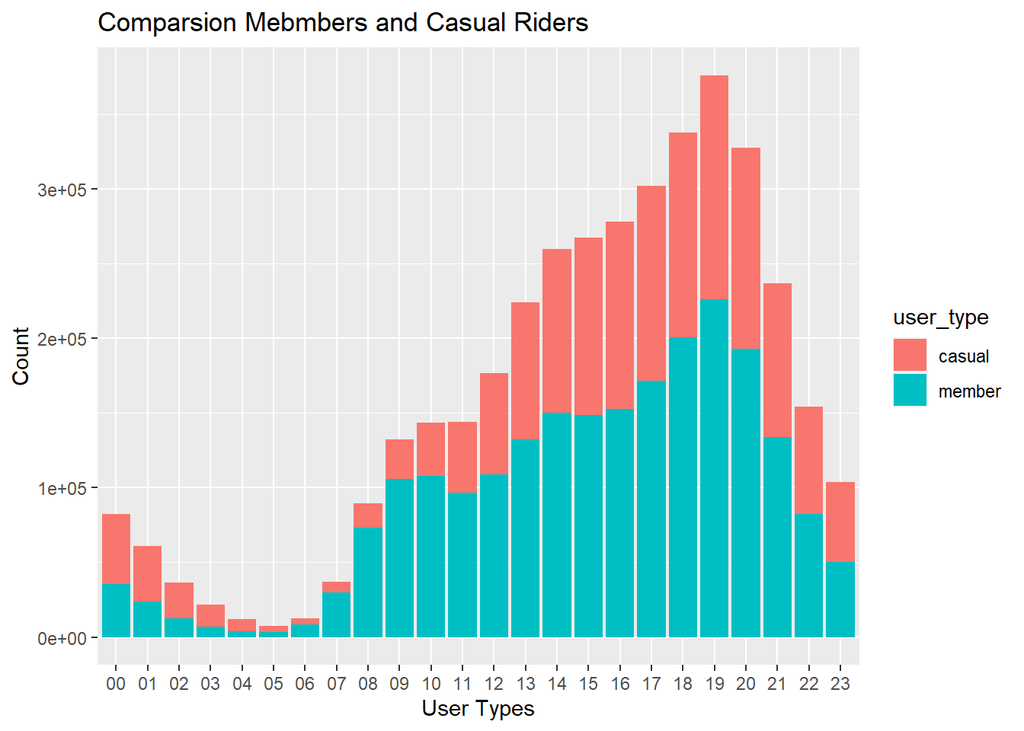

```r
#Hourly distribution of rides

fig(16,10)
ggplot(df, aes(hour, fill = user_type)) + geom_bar() + labs(x = "User Types", y = "Count", title = "Comparsion Mebmbers and Casual Riders")
```

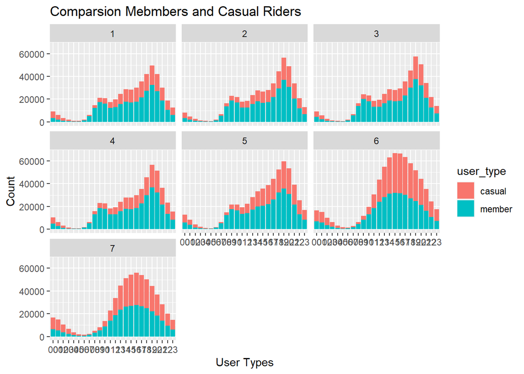

```r
fig(16,10)
ggplot(df, aes(hour, fill = user_type)) + geom_bar() + labs(x = "User Types", y = "Count", title = "Comparsion Mebmbers and Casual Riders") + facet_wrap(~day)
```

**Findings:**

- In the morning hours mainly members use the bikes
- The number of casual riders increases throughout the day
- On Saturday and Sunday distribution of the rides is smoother than on weekdays where its steep
- Most casual riders take a ride on saturday from 11 am to 6 pm

```r
#Distribution of Rideable Types

df %>% group_by(bike_id) %>%
        summarise(count = length(ride_id)
            ,'%' = length(ride_id)/nrow(df)*100
            ,'casual_p' = sum(user_type == "casual")/ length(ride_id)*100
            ,'members_p' = sum(user_type == "member")/ length(ride_id))
```

```
## # A tibble: 3 x 5
##   bike_id         count   `%` casual_p members_p
##   <chr>           <int> <dbl>    <dbl>     <dbl>
## 1 classic_bike   534492  14.0     26.5     0.735
## 2 docked_bike   2582974  67.5     44.2     0.558
## 3 electric_bike  709303  18.5     40.1     0.599
```

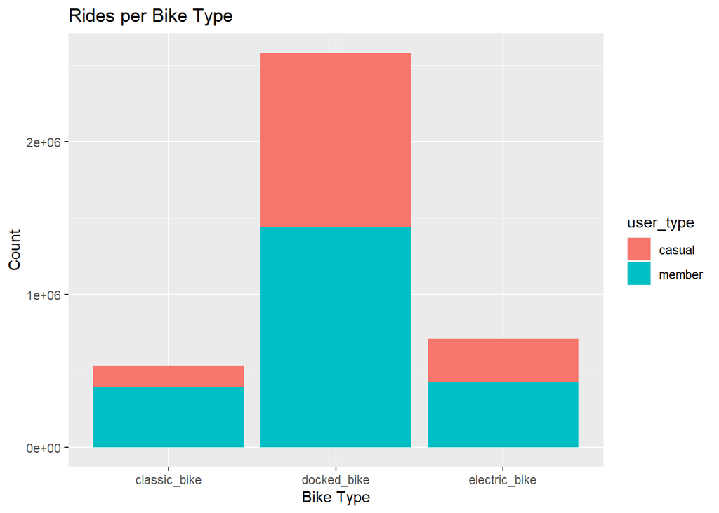

```r
fig(16,10)
ggplot(df, aes(bike_id, fill = user_type)) + geom_bar() + labs(y = "Count", x = "Bike Type", title = "Rides per Bike Type" )
```

**Findings:** * The docked bikes are the most popular bike type * Casual Riders mostly use the docked bike * Members use the classic and electric bike on a higher volume than casual riders

### Now, lets take a look at the ride times

```r
summary(df$ride_time)
```

```
##      Min.   1st Qu.    Median      Mean   3rd Qu.      Max.
## -29049.97      7.80     14.35     26.27     26.38  58720.03
```

```r
#analzye the quantiles to choose which subset without outliers could be used for further analysis --> 95% of Data will be used
quantiles = quantile(df$ride_time, seq(0, 1, by=0.05))
quantiles
```

```
##            0%            5%           10%           15%           20%
## -29049.966667      3.083333      4.483333      5.633333      6.716667
##           25%           30%           35%           40%           45%
##      7.800000      8.933333     10.133333     11.400000     12.800000
##           50%           55%           60%           65%           70%
##     14.350000     16.100000     18.100000     20.416667     23.150000
##           75%           80%           85%           90%           95%
##     26.383333     30.333333     36.116667     45.700000     72.166667
##          100%
##  58720.033333
```

```r
df_no_outliers <- df %>%
    filter(ride_time > quantiles['5%']) %>%
    filter(ride_time < quantiles['95%'])
```

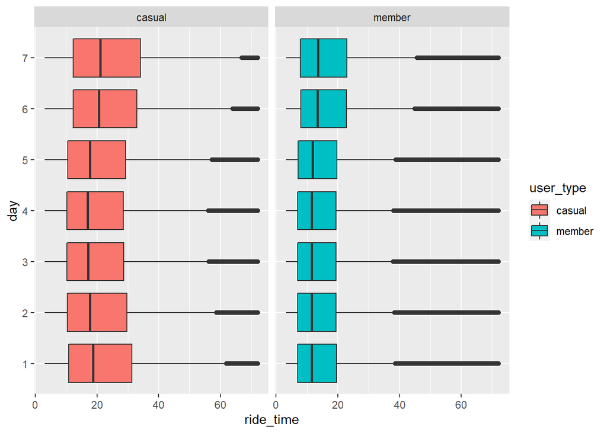

```r
fig(16,10)
ggplot(df_no_outliers, aes(x = ride_time, y = day, fill = user_type)) +
    geom_boxplot() + facet_wrap(~user_type)
```

**Findings:** * Casual Riders have more ride time than members

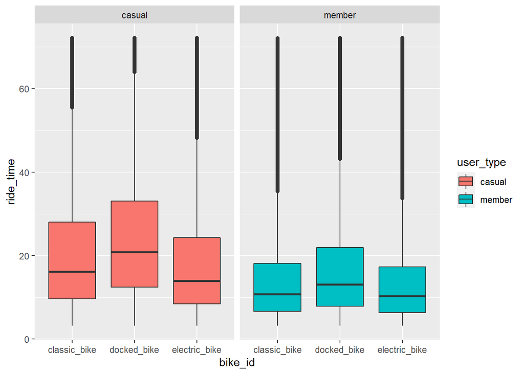

```r
fig(16,10)
ggplot(df_no_outliers, aes(x = ride_time, y = bike_id, fill = user_type)) +
    geom_boxplot() + facet_wrap(~user_type) + coord_flip()
```

**Findings:** * For both user types the docked bikes have the highest ride time

## **Step 5: Share**

### Guiding Questions

Were you able to answer the question of how annual members and casual riders use Cyclistic bikes differently? * Yes the analysis answers this question

What story does your data tell? * It shows how members and casual riders use the bikes from cyclistic different

How do your findings relate to your original question? * The key task for this analysis was to find the differences between casual riders and annual members. This was successful.

Who is your audience? What is the best way to communicate with them? * The audience is the marketing team. * The best way to communicate with them would be to build a high-level presentation with the key findings of this analysis

Can data visualization help you share your findings? * Yes, the visualisations make the findings easier to understand

Is your presentation accessible to your audience? * Yes

## **Step 6: Act**

### Guiding Questions

How could your team and business apply your insights? * The insights can be used to better address casual riders with marketing campaigns and convert to annual members

What next steps would you or your stakeholders take based on your findings? * There is always room for more analysis * The marketing team has to take the next steps and work based on the findings

Is there additional data you could use to expand on your findings? * Data about the demographics of members and casuals * Weather data